# Modeling and prediction for movies

## Setup

### Load packages

```r
library(ggplot2)
library(dplyr)
library(statsr)
library(GGally)
```

### Load data

```r
load("movies.Rdata")
dim(movies)
```

```
## [1] 651  32
```

## Part 1: Data

The data set is comprised of 651 randomly sampled movies produced and released before 2016, with information from Rotten Tomatoes and IMDB. These information are stored across 32 variables, both numerical and categorical.

Generalizability: Random sampling is used to collect the data, therefore the data is generalizable to the whole population of movies produced and released before 2016 in the US.

Casuality: This is a observational data set, not experimental. No random assignment was used. Therefore any relationship between variables from the data set can only indicate association but not causation.

Bias: Potential biases might come from non-voting (or non-rating) behavior of movie viewers, since rating and voting on IMDB and rotten-tomatoes are voluntary.

## Part 2: Research question

In this study I intend to study whether a movie’s audience score, which reflects its popularity, is associated with a number of variables: type of movie, genre, runtime, imdb rating, imdb number of votes, critics rating, critics score, audience rating and major rewards.

I am interested in this question because being able to predict movies’ popularity can be extremely helpful for business decision making in entertainment industry and investors.

## Part 3: Exploratory data analysis

### Selecting variables

The movies data set contains 32 variables. Some of the variables are clearly not relavant for making predictions on audience score of movies, such as the URL of the movies, or the names of the leading actors/actresses. I decide to choose following variables as starting point for the regression study:

1. title_type: Type of movie (Documentary, Feature Film, TV Movie)
2. genre: Genre of movie (Action & Adventure, Comedy, Documentary, Drama, Horror, Mystery & Suspense, Other)
3. runtime: Runtime of movie (in minutes)
4. mpaa_rating: MPAA rating of the movie (G, PG, PG-13, R, Unrated)
5. imdb_rating: Rating on IMDB
6. imdb_num_votes: Number of votes on IMDB
7. critics_rating: Categorical variable for critics rating on Rotten Tomatoes (Certified Fresh, Fresh, Rotten)
8. critics_score: Critics score on Rotten Tomatoes
9. audience_rating: Categorical variable for audience rating on Rotten Tomatoes (Spilled, Upright)
10. audience_score: Audience score on Rotten Tomatoes
11. best_pic_nom: Whether or not the movie was nominated for a best picture Oscar (no, yes)
12. best_pic_win: Whether or not the movie won a best picture Oscar (no, yes)
13. best_actor_win: Whether or not one of the main actors in the movie ever won an Oscar (no, yes)
14. best_actress_win: Whether or not one of the main actresses in the movie ever won an Oscar (no, yes)
15. best_dir_win: Whether or not the director of the movie ever won an Oscar (no, yes)
16. top200_box: Whether or not the movie is in the Top 200 Box Office list on BoxOfficeMojo (no, yes)

Here I create a new dataframe to contact the above selected variables:

```r
movie_data <- movies %>%
  select(title_type, genre, mpaa_rating, critics_rating, audience_rating, best_pic_nom, best_pic_win, best_actor_win,
         best_actress_win, best_dir_win, top200_box, runtime, imdb_rating, imdb_num_votes, critics_score, audience_score)

str(movie_data)
```

```
## Classes 'tbl_df', 'tbl' and 'data.frame':    651 obs. of  16 variables:
##  $ title_type      : Factor w/ 3 levels "Documentary",..: 2 2 2 2 2 1 2 2 1 2 ...
##  $ genre           : Factor w/ 11 levels "Action & Adventure",..: 6 6 4 6 7 5 6 6 5 6 ...
##  $ mpaa_rating     : Factor w/ 6 levels "G","NC-17","PG",..: 5 4 5 3 5 6 4 5 6 6 ...
##  $ critics_rating  : Factor w/ 3 levels "Certified Fresh",..: 3 1 1 1 3 2 3 3 2 1 ...
##  $ audience_rating : Factor w/ 2 levels "Spilled","Upright": 2 2 2 2 1 2 2 1 2 2 ...
##  $ best_pic_nom    : Factor w/ 2 levels "no","yes": 1 1 1 1 1 1 1 1 1 1 ...
##  $ best_pic_win    : Factor w/ 2 levels "no","yes": 1 1 1 1 1 1 1 1 1 1 ...
##  $ best_actor_win  : Factor w/ 2 levels "no","yes": 1 1 1 2 1 1 1 2 1 1 ...
##  $ best_actress_win: Factor w/ 2 levels "no","yes": 1 1 1 1 1 1 1 1 1 1 ...
##  $ best_dir_win    : Factor w/ 2 levels "no","yes": 1 1 1 2 1 1 1 1 1 1 ...
##  $ top200_box      : Factor w/ 2 levels "no","yes": 1 1 1 1 1 1 1 1 1 1 ...
##  $ runtime         : num  80 101 84 139 90 78 142 93 88 119 ...
##  $ imdb_rating     : num  5.5 7.3 7.6 7.2 5.1 7.8 7.2 5.5 7.5 6.6 ...
##  $ imdb_num_votes  : int  899 12285 22381 35096 2386 333 5016 2272 880 12496 ...
##  $ critics_score   : num  45 96 91 80 33 91 57 17 90 83 ...
##  $ audience_score  : num  73 81 91 76 27 86 76 47 89 66 ...
```

```r
summary(movie_data)
```

```
##         title_type                 genre      mpaa_rating
##  Documentary : 55   Drama             :305   G      : 19
##  Feature Film:591   Comedy            : 87   NC-17  :  2
##  TV Movie    :  5   Action & Adventure: 65   PG     :118
##                     Mystery & Suspense: 59   PG-13  :133
##                     Documentary       : 52   R      :329
##                     Horror            : 23   Unrated: 50
##                     (Other)           : 60
##          critics_rating audience_rating best_pic_nom best_pic_win
##  Certified Fresh:135    Spilled:275     no :629      no :644
##  Fresh          :209    Upright:376     yes: 22      yes:  7
##  Rotten         :307
##
##
##
##
##  best_actor_win best_actress_win best_dir_win top200_box    runtime
##  no :558        no :579          no :608      no :636    Min.   : 39.0
##  yes: 93        yes: 72          yes: 43      yes: 15    1st Qu.: 92.0
##                                                          Median :103.0
##                                                          Mean   :105.8
##                                                          3rd Qu.:115.8
##                                                          Max.   :267.0
##                                                          NA's   :1
##   imdb_rating    imdb_num_votes   critics_score    audience_score
##  Min.   :1.900   Min.   :   180   Min.   :  1.00   Min.   :11.00
##  1st Qu.:5.900   1st Qu.:  4546   1st Qu.: 33.00   1st Qu.:46.00
##  Median :6.600   Median : 15116   Median : 61.00   Median :65.00
##  Mean   :6.493   Mean   : 57533   Mean   : 57.69   Mean   :62.36
##  3rd Qu.:7.300   3rd Qu.: 58301   3rd Qu.: 83.00   3rd Qu.:80.00
##  Max.   :9.000   Max.   :893008   Max.   :100.00   Max.   :97.00
##
```

There’s one entry with missing values. I decide to remove the entry.

```r
movie_data <- na.omit(movie_data)
```

### Distribution of numerical variables

Then I decide to take a look at distribution of the responsive variable, audience score:

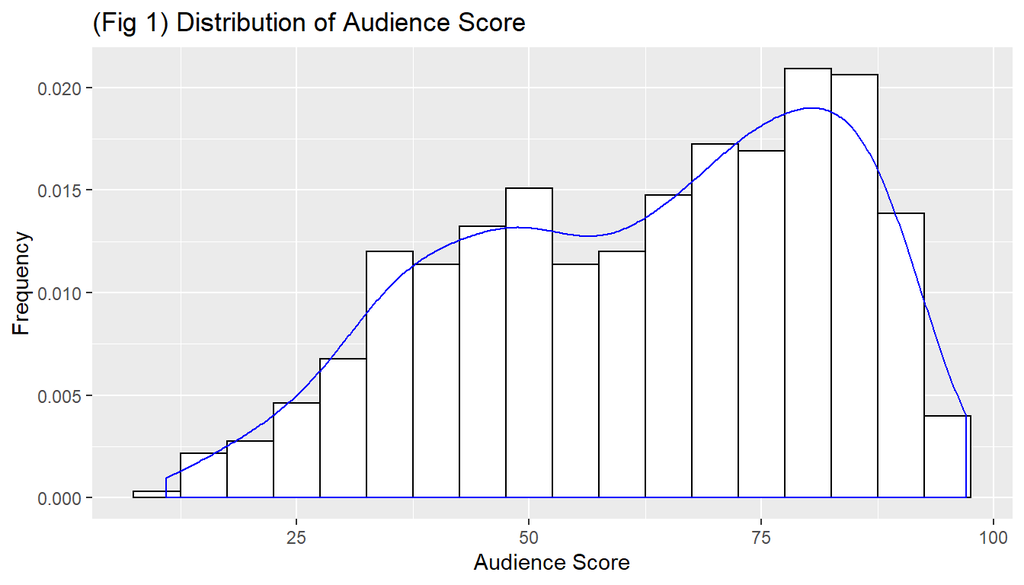

```r
ggplot(movie_data, aes(audience_score, ..density.. )) +
  geom_histogram(binwidth = 5, color='black', fill='white') +
  xlab("Audience Score") + ylab("Frequency") +
  geom_density(col = "blue", lwd = 0.5) +
  ggtitle("(Fig 1) Distribution of Audience Score")
```

```r
summary(movie_data$audience_score)
```

```
##    Min. 1st Qu.  Median    Mean 3rd Qu.    Max.
##   11.00   46.00   65.00   62.35   80.00   97.00
```

The distribution of audience score is slightly left-skewed, with a median of 65.00 and mean of 62.35.

Next, I would like to view distribution of all numeric variables to be included in the initial model using histograms:

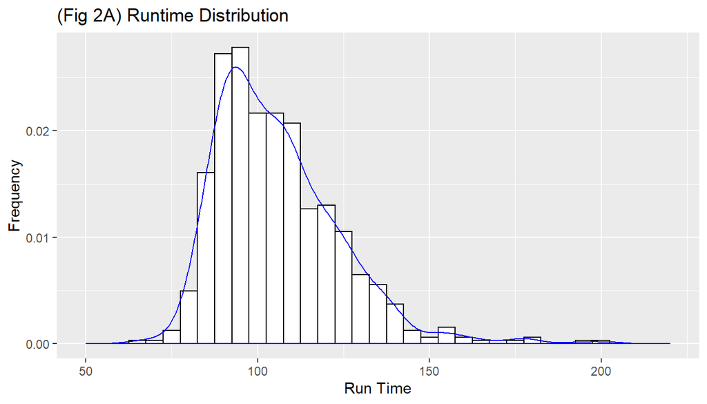

```r
ggplot(movie_data, aes(runtime, ..density.. )) +
  geom_histogram(binwidth = 5, color='black', fill='white') +
  xlab("Run Time") + ylab("Frequency") + xlim(50, 220) +
  geom_density(col = "blue", lwd = 0.5) +
  ggtitle("(Fig 2A) Runtime Distribution")
```

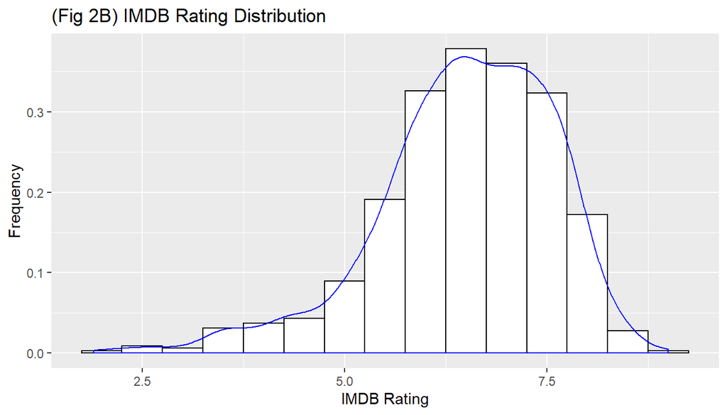

```r
ggplot(movie_data, aes(imdb_rating, ..density.. ))+
  geom_histogram(binwidth = 0.5, color='black', fill='white') +
  xlab("IMDB Rating") + ylab("Frequency") +
  geom_density(col = "blue", lwd = 0.5) +
  ggtitle("(Fig 2B) IMDB Rating Distribution")
```

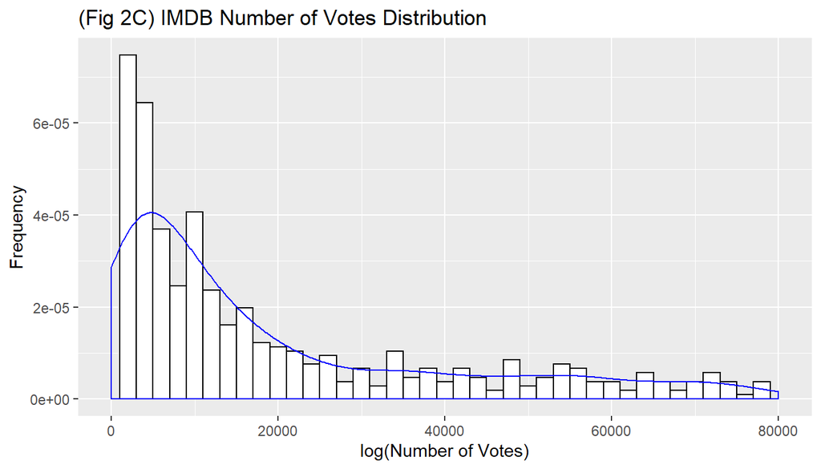

```r
ggplot(movie_data, aes(imdb_num_votes, ..density.. )) +
  geom_histogram(binwidth = 2000, color='black', fill='white') +
  xlab("log(Number of Votes)") + ylab("Frequency") + xlim(0,80000) +
  geom_density(col = "blue", lwd = 0.5) +
  ggtitle("(Fig 2C) IMDB Number of Votes Distribution")
```

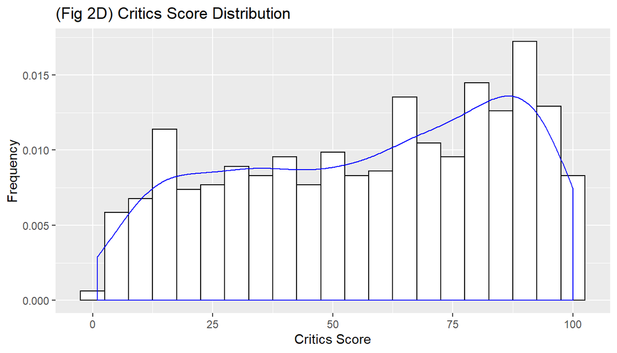

```r
ggplot(movie_data, aes(critics_score, ..density..)) +
  geom_histogram(binwidth = 5, color='black', fill='white') +
  xlab("Critics Score") + ylab("Frequency") +
  geom_density(col = "blue", lwd = 0.5) +
  ggtitle("(Fig 2D) Critics Score Distribution")
```

All 4 numerical variables are broadly distributed, with runtime slightly right skewed, imdb_rating slightly left skewed, imdb_num_votes extremely right skewed and critics_score distribution left skewed and relatively flat compared to other variables.

### Distribution of categorical variables

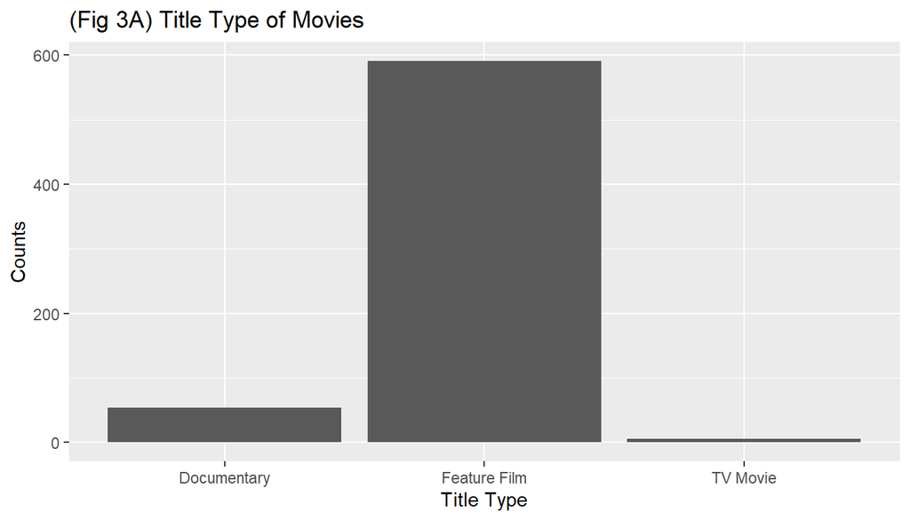

```r
ggplot(movie_data, aes(title_type)) +
  geom_bar() +
  xlab("Title Type") + ylab("Counts") +
  ggtitle("(Fig 3A) Title Type of Movies")
```

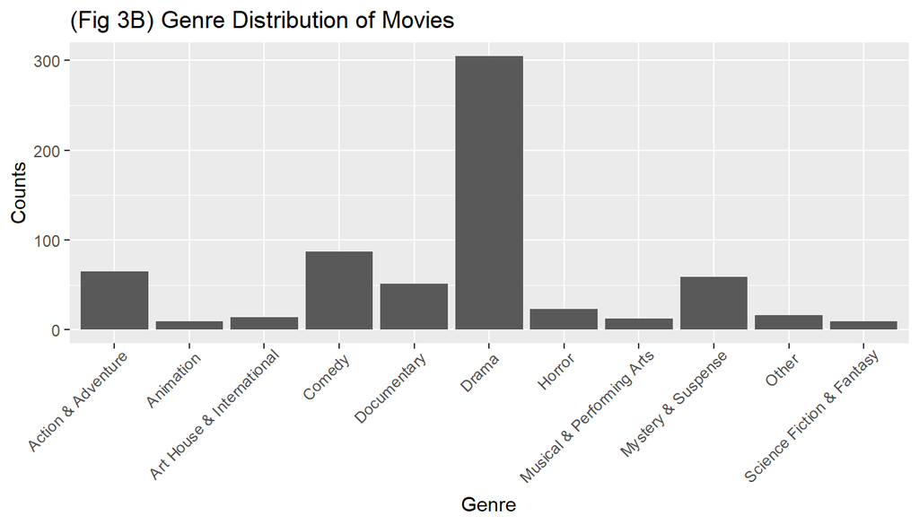

```r
ggplot(movie_data, aes(genre)) +
  geom_bar() +
  xlab("Genre") + ylab("Counts") +
  theme(axis.text.x = element_text(angle=45, hjust=0.95)) +
  ggtitle("(Fig 3B) Genre Distribution of Movies")
```

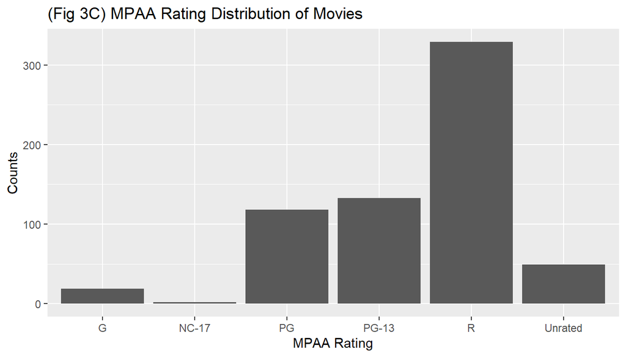

```r
ggplot(movie_data, aes(mpaa_rating)) +
  geom_bar() +
  xlab("MPAA Rating") + ylab("Counts") +
  ggtitle("(Fig 3C) MPAA Rating Distribution of Movies")
```

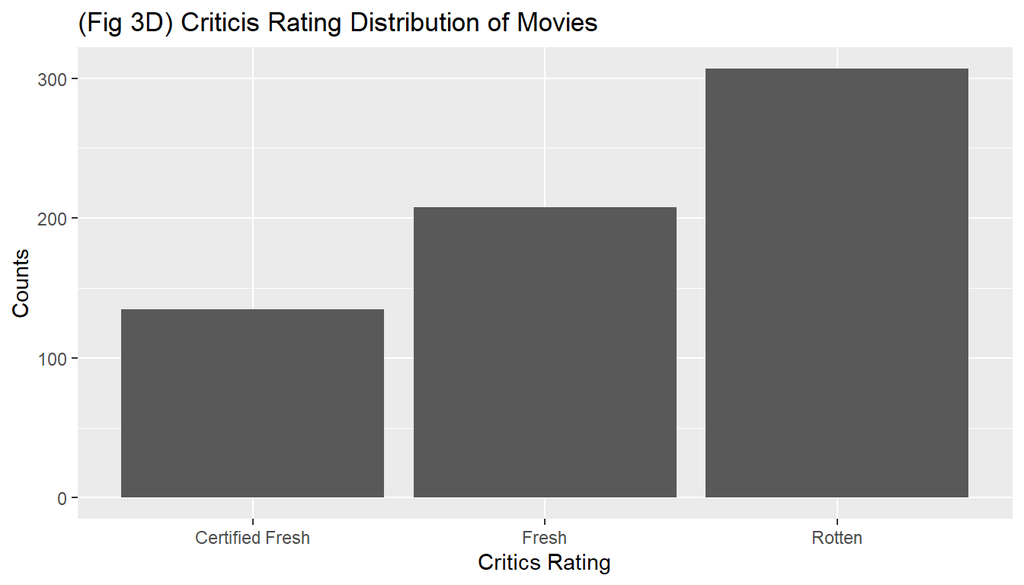

```r
ggplot(movie_data, aes(critics_rating)) +
  geom_bar() +
  xlab("Critics Rating") + ylab("Counts") +
  ggtitle("(Fig 3D) Criticis Rating Distribution of Movies")
```

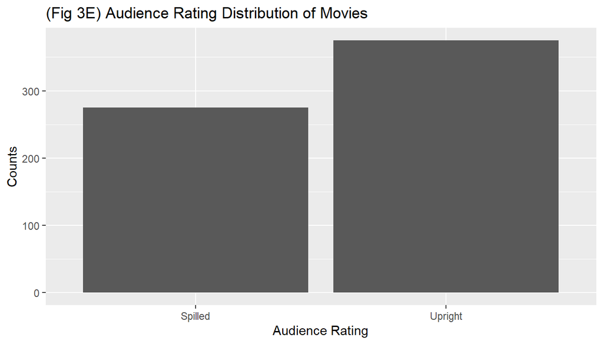

```r
ggplot(movie_data, aes(audience_rating)) +
  geom_bar() +
  xlab("Audience Rating") + ylab("Counts") +
  ggtitle("(Fig 3E) Audience Rating Distribution of Movies")
```

### Correlation between numerical variables

Next, I look at correlation between numeric variables using pairplot:

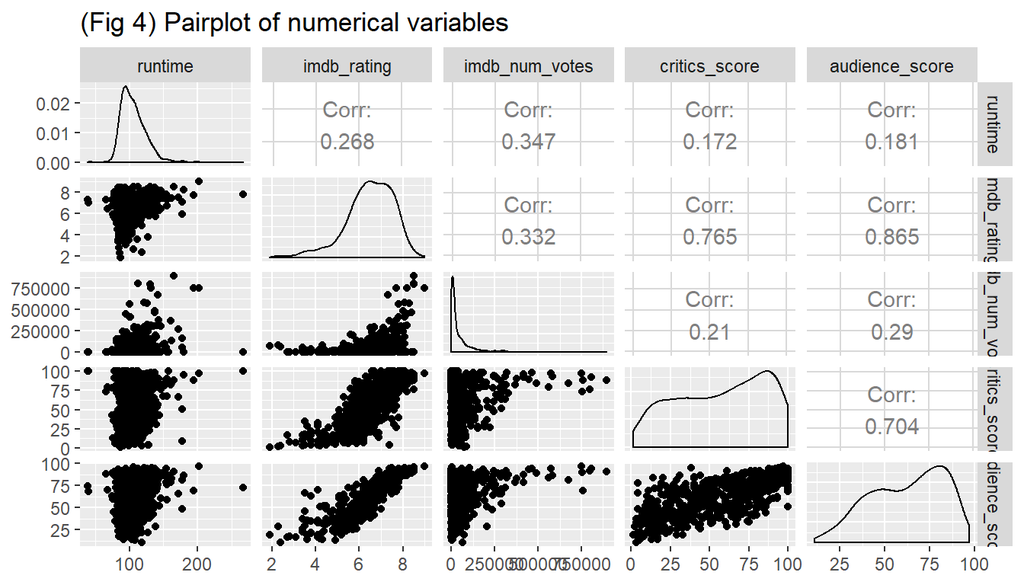

```r
ggpairs(movie_data, columns = 12:16) +
  ggtitle("(Fig 4) Pairplot of numerical variables")
```

From the pair plot, it seems like audience_score is strongly correlated with imdb_rating and critics_score. However, imdb_rating and critics_score are also highly correlated, with correlation of 0.765. Therefore, we need to be causious when selection for prediction models, since the two variables might be redundant due to colinearity.

## Part 4: Modeling

### Method selection

I decide fit the model with linear regression. To pick the set of variables to be included in the model, I decide to use backward selection based on p-value. Compared to forward selection, backward selection fits less models. Similarly, even though using R-squared generates more reliable model, using p-value requires less models to be fitted.

There are other criteria to be used such as Cp, AIC and BIC, and there are convenient functions and packages for model selection. However here I will do each step manually by looking at p-value for different variables.

### Backward selection

I started with a model using all variables: m_full

```r
m_full <- lm(audience_score ~ ., data = movie_data)

summary(m_full)
```

```
##
## Call:
## lm(formula = audience_score ~ ., data = movie_data)
##
## Residuals:
##      Min       1Q   Median       3Q      Max
## -22.3327  -4.3939   0.3987   4.2976  24.3401
##
## Coefficients:
##                                  Estimate Std. Error t value Pr(>|t|)
## (Intercept)                    -9.088e+00  4.494e+00  -2.023   0.0436 *
## title_typeFeature Film          2.469e+00  2.577e+00   0.958   0.3383
## title_typeTV Movie              9.358e-01  4.042e+00   0.232   0.8170
## genreAnimation                  2.477e+00  2.717e+00   0.912   0.3623
## genreArt House & International -2.337e+00  2.111e+00  -1.107   0.2686
## genreComedy                     1.618e+00  1.159e+00   1.397   0.1630
## genreDocumentary                2.545e+00  2.762e+00   0.921   0.3572
## genreDrama                     -4.135e-01  1.024e+00  -0.404   0.6866
## genreHorror                    -1.691e+00  1.727e+00  -0.979   0.3280
## genreMusical & Performing Arts  3.785e+00  2.371e+00   1.597   0.1109
## genreMystery & Suspense        -2.770e+00  1.305e+00  -2.123   0.0342 *
## genreOther                     -1.547e-01  1.968e+00  -0.079   0.9374
## genreScience Fiction & Fantasy -2.709e-01  2.463e+00  -0.110   0.9125
## mpaa_ratingNC-17               -6.803e-01  5.235e+00  -0.130   0.8966
## mpaa_ratingPG                  -1.861e-01  1.907e+00  -0.098   0.9223
## mpaa_ratingPG-13               -1.125e+00  1.974e+00  -0.570   0.5692
## mpaa_ratingR                   -1.296e+00  1.904e+00  -0.681   0.4963
## mpaa_ratingUnrated             -3.254e-01  2.179e+00  -0.149   0.8813
## critics_ratingFresh             1.535e-01  8.691e-01   0.177   0.8599
## critics_ratingRotten           -6.669e-01  1.402e+00  -0.476   0.6344
## audience_ratingUpright          2.004e+01  7.924e-01  25.289   <2e-16 ***
## best_pic_nomyes                 3.719e+00  1.811e+00   2.053   0.0405 *
## best_pic_winyes                -2.523e+00  3.192e+00  -0.790   0.4297
## best_actor_winyes              -6.606e-03  8.224e-01  -0.008   0.9936
## best_actress_winyes            -1.267e+00  9.100e-01  -1.392   0.1643
## best_dir_winyes                 3.046e-01  1.192e+00   0.256   0.7984
## top200_boxyes                  -6.564e-01  1.936e+00  -0.339   0.7347
## runtime                        -2.706e-02  1.702e-02  -1.590   0.1123
## imdb_rating                     9.403e+00  4.893e-01  19.218   <2e-16 ***
## imdb_num_votes                  3.332e-06  3.234e-06   1.030   0.3033
## critics_score                   9.438e-03  2.527e-02   0.373   0.7089
## ---
## Signif. codes:  0 '***' 0.001 '**' 0.01 '*' 0.05 '.' 0.1 ' ' 1
##
## Residual standard error: 6.871 on 619 degrees of freedom
## Multiple R-squared:   0.89,  Adjusted R-squared:  0.8847
## F-statistic:   167 on 30 and 619 DF,  p-value: < 2.2e-16
```

Based on the full model, the variable with the highest p-value is best_actor, so the I decide to drop this variable and fit a new model m_minus_one:

```r
m_minus_one <- lm(audience_score ~ title_type + genre + runtime + mpaa_rating + imdb_rating + imdb_num_votes +
                    critics_rating + critics_score + audience_rating + best_pic_nom + best_pic_win + best_actress_win + best_dir_win + top200_box, data = movie_data)

summary(m_minus_one)
```

```
##
## Call:
## lm(formula = audience_score ~ title_type + genre + runtime +
##     mpaa_rating + imdb_rating + imdb_num_votes + critics_rating +
##     critics_score + audience_rating + best_pic_nom + best_pic_win +
##     best_actress_win + best_dir_win + top200_box, data = movie_data)
##
## Residuals:
##      Min       1Q   Median       3Q      Max
## -22.3314  -4.3931   0.4002   4.2983  24.3407
##
## Coefficients:
##                                  Estimate Std. Error t value Pr(>|t|)
## (Intercept)                    -9.086e+00  4.476e+00  -2.030   0.0428 *
## title_typeFeature Film          2.469e+00  2.575e+00   0.959   0.3380
## title_typeTV Movie              9.364e-01  4.038e+00   0.232   0.8167
## genreAnimation                  2.477e+00  2.714e+00   0.913   0.3618
## genreArt House & International -2.337e+00  2.108e+00  -1.108   0.2682
## genreComedy                     1.618e+00  1.158e+00   1.398   0.1627
## genreDocumentary                2.545e+00  2.760e+00   0.922   0.3568
## genreDrama                     -4.137e-01  1.023e+00  -0.404   0.6860
## genreHorror                    -1.690e+00  1.725e+00  -0.980   0.3276
## genreMusical & Performing Arts  3.785e+00  2.369e+00   1.598   0.1105
## genreMystery & Suspense        -2.771e+00  1.300e+00  -2.132   0.0334 *
## genreOther                     -1.548e-01  1.967e+00  -0.079   0.9373
## genreScience Fiction & Fantasy -2.702e-01  2.459e+00  -0.110   0.9126
## runtime                        -2.708e-02  1.672e-02  -1.620   0.1057
## mpaa_ratingNC-17               -6.829e-01  5.220e+00  -0.131   0.8960
## mpaa_ratingPG                  -1.866e-01  1.905e+00  -0.098   0.9220
## mpaa_ratingPG-13               -1.125e+00  1.973e+00  -0.570   0.5688
## mpaa_ratingR                   -1.296e+00  1.903e+00  -0.681   0.4959
## mpaa_ratingUnrated             -3.253e-01  2.177e+00  -0.149   0.8813
## imdb_rating                     9.403e+00  4.887e-01  19.240   <2e-16 ***
## imdb_num_votes                  3.332e-06  3.230e-06   1.032   0.3027
## critics_ratingFresh             1.533e-01  8.681e-01   0.177   0.8599
## critics_ratingRotten           -6.670e-01  1.401e+00  -0.476   0.6341
## critics_score                   9.438e-03  2.525e-02   0.374   0.7087
## audience_ratingUpright          2.004e+01  7.904e-01  25.353   <2e-16 ***
## best_pic_nomyes                 3.717e+00  1.797e+00   2.068   0.0390 *
## best_pic_winyes                -2.521e+00  3.181e+00  -0.792   0.4284
## best_actress_winyes            -1.268e+00  9.078e-01  -1.396   0.1632
## best_dir_winyes                 3.042e-01  1.190e+00   0.256   0.7983
## top200_boxyes                  -6.568e-01  1.933e+00  -0.340   0.7342
## ---
## Signif. codes:  0 '***' 0.001 '**' 0.01 '*' 0.05 '.' 0.1 ' ' 1
##
## Residual standard error: 6.866 on 620 degrees of freedom
## Multiple R-squared:   0.89,  Adjusted R-squared:  0.8849
## F-statistic:   173 on 29 and 620 DF,  p-value: < 2.2e-16
```

```r
m_minus_two <- lm(audience_score ~ title_type + genre + runtime + mpaa_rating + imdb_rating + imdb_num_votes +
                    critics_rating + critics_score + audience_rating + best_pic_nom + best_pic_win + best_actress_win + top200_box, data = movie_data)

summary(m_minus_two)
```

```
##
## Call:
## lm(formula = audience_score ~ title_type + genre + runtime +
##     mpaa_rating + imdb_rating + imdb_num_votes + critics_rating +
##     critics_score + audience_rating + best_pic_nom + best_pic_win +
##     best_actress_win + top200_box, data = movie_data)
##
## Residuals:
##      Min       1Q   Median       3Q      Max
## -22.3378  -4.3995   0.4725   4.3214  24.3426
##
## Coefficients:
##                                  Estimate Std. Error t value Pr(>|t|)
## (Intercept)                    -9.198e+00  4.451e+00  -2.067   0.0392 *
## title_typeFeature Film          2.491e+00  2.571e+00   0.969   0.3331
## title_typeTV Movie              9.483e-01  4.035e+00   0.235   0.8143
## genreAnimation                  2.476e+00  2.712e+00   0.913   0.3616
## genreArt House & International -2.354e+00  2.106e+00  -1.118   0.2639
## genreComedy                     1.616e+00  1.157e+00   1.397   0.1629
## genreDocumentary                2.546e+00  2.758e+00   0.923   0.3564
## genreDrama                     -4.222e-01  1.022e+00  -0.413   0.6796
## genreHorror                    -1.690e+00  1.724e+00  -0.981   0.3272
## genreMusical & Performing Arts  3.782e+00  2.367e+00   1.598   0.1105
## genreMystery & Suspense        -2.775e+00  1.299e+00  -2.137   0.0330 *
## genreOther                     -1.656e-01  1.965e+00  -0.084   0.9329
## genreScience Fiction & Fantasy -2.569e-01  2.457e+00  -0.105   0.9168
## runtime                        -2.640e-02  1.649e-02  -1.601   0.1099
## mpaa_ratingNC-17               -6.938e-01  5.216e+00  -0.133   0.8942
## mpaa_ratingPG                  -1.721e-01  1.903e+00  -0.090   0.9280
## mpaa_ratingPG-13               -1.116e+00  1.971e+00  -0.566   0.5714
## mpaa_ratingR                   -1.283e+00  1.901e+00  -0.675   0.4999
## mpaa_ratingUnrated             -3.292e-01  2.175e+00  -0.151   0.8798
## imdb_rating                     9.408e+00  4.881e-01  19.275   <2e-16 ***
## imdb_num_votes                  3.349e-06  3.227e-06   1.038   0.2998
## critics_ratingFresh             1.611e-01  8.669e-01   0.186   0.8526
## critics_ratingRotten           -6.715e-01  1.400e+00  -0.480   0.6316
## critics_score                   9.599e-03  2.522e-02   0.381   0.7036
## audience_ratingUpright          2.003e+01  7.891e-01  25.386   <2e-16 ***
## best_pic_nomyes                 3.690e+00  1.793e+00   2.058   0.0400 *
## best_pic_winyes                -2.296e+00  3.055e+00  -0.752   0.4526
## best_actress_winyes            -1.266e+00  9.071e-01  -1.396   0.1632
## top200_boxyes                  -6.681e-01  1.931e+00  -0.346   0.7295
## ---
## Signif. codes:  0 '***' 0.001 '**' 0.01 '*' 0.05 '.' 0.1 ' ' 1
##
## Residual standard error: 6.86 on 621 degrees of freedom
## Multiple R-squared:   0.89,  Adjusted R-squared:  0.885
## F-statistic: 179.5 on 28 and 621 DF,  p-value: < 2.2e-16
```

The next variable to be dropped is top200_box, with a p-value of 0.7295.

```r
m_minus_three <- lm(audience_score ~ title_type + genre + runtime + mpaa_rating + imdb_rating + imdb_num_votes +
                      critics_rating + critics_score + audience_rating + best_pic_nom + best_pic_win + best_actress_win, data = movie_data)

summary(m_minus_three)
```

```
##
## Call:
## lm(formula = audience_score ~ title_type + genre + runtime +
##     mpaa_rating + imdb_rating + imdb_num_votes + critics_rating +
##     critics_score + audience_rating + best_pic_nom + best_pic_win +
##     best_actress_win, data = movie_data)
##
## Residuals:
##      Min       1Q   Median       3Q      Max
## -22.3219  -4.3987   0.4741   4.3402  24.3455
##
## Coefficients:
##                                  Estimate Std. Error t value Pr(>|t|)
## (Intercept)                    -9.309e+00  4.436e+00  -2.098   0.0363 *
## title_typeFeature Film          2.484e+00  2.569e+00   0.967   0.3339
## title_typeTV Movie              9.383e-01  4.032e+00   0.233   0.8161
## genreAnimation                  2.577e+00  2.694e+00   0.957   0.3392
## genreArt House & International -2.332e+00  2.103e+00  -1.109   0.2680
## genreComedy                     1.644e+00  1.153e+00   1.426   0.1543
## genreDocumentary                2.572e+00  2.755e+00   0.934   0.3508
## genreDrama                     -3.935e-01  1.018e+00  -0.387   0.6991
## genreHorror                    -1.672e+00  1.722e+00  -0.971   0.3319
## genreMusical & Performing Arts  3.818e+00  2.363e+00   1.616   0.1066
## genreMystery & Suspense        -2.747e+00  1.295e+00  -2.121   0.0343 *
## genreOther                     -1.430e-01  1.962e+00  -0.073   0.9420
## genreScience Fiction & Fantasy -2.728e-01  2.455e+00  -0.111   0.9115
## runtime                        -2.675e-02  1.645e-02  -1.627   0.1043
## mpaa_ratingNC-17               -6.100e-01  5.207e+00  -0.117   0.9068
## mpaa_ratingPG                  -1.172e-01  1.895e+00  -0.062   0.9507
## mpaa_ratingPG-13               -1.036e+00  1.956e+00  -0.530   0.5964
## mpaa_ratingR                   -1.194e+00  1.882e+00  -0.635   0.5259
## mpaa_ratingUnrated             -2.512e-01  2.162e+00  -0.116   0.9076
## imdb_rating                     9.416e+00  4.871e-01  19.331   <2e-16 ***
## imdb_num_votes                  3.116e-06  3.154e-06   0.988   0.3235
## critics_ratingFresh             1.786e-01  8.648e-01   0.206   0.8365
## critics_ratingRotten           -6.561e-01  1.398e+00  -0.469   0.6390
## critics_score                   9.368e-03  2.519e-02   0.372   0.7102
## audience_ratingUpright          2.002e+01  7.880e-01  25.408   <2e-16 ***
## best_pic_nomyes                 3.708e+00  1.791e+00   2.071   0.0388 *
## best_pic_winyes                -2.281e+00  3.053e+00  -0.747   0.4552
## best_actress_winyes            -1.282e+00  9.054e-01  -1.416   0.1573
## ---
## Signif. codes:  0 '***' 0.001 '**' 0.01 '*' 0.05 '.' 0.1 ' ' 1
##
## Residual standard error: 6.856 on 622 degrees of freedom
## Multiple R-squared:   0.89,  Adjusted R-squared:  0.8852
## F-statistic: 186.4 on 27 and 622 DF,  p-value: < 2.2e-16
```

The next variable to be dropped is critics_score, with p-value of 0.7102. Note that critics_score is highly correlated with imdb_rating, therefore it is not surprising that when both variables are included in the model, one of the two becomes redundant and has large p-value.

The step of drop one variables continues, each time drop the variable with highest p-value:

```r
m_minus_four <- lm(audience_score ~ title_type + genre + runtime + mpaa_rating + imdb_rating + imdb_num_votes +
                     critics_rating + audience_rating + best_pic_nom + best_pic_win + best_actress_win, data = movie_data)

summary(m_minus_four)
```

```
##
## Call:
## lm(formula = audience_score ~ title_type + genre + runtime +
##     mpaa_rating + imdb_rating + imdb_num_votes + critics_rating +
##     audience_rating + best_pic_nom + best_pic_win + best_actress_win,
##     data = movie_data)
##
## Residuals:
##      Min       1Q   Median       3Q      Max
## -22.5300  -4.3847   0.4686   4.3534  24.5686
##
## Coefficients:
##                                  Estimate Std. Error t value Pr(>|t|)
## (Intercept)                    -9.022e+00  4.366e+00  -2.067   0.0392 *
## title_typeFeature Film          2.397e+00  2.557e+00   0.938   0.3488
## title_typeTV Movie              8.867e-01  4.027e+00   0.220   0.8258
## genreAnimation                  2.562e+00  2.692e+00   0.952   0.3416
## genreArt House & International -2.383e+00  2.097e+00  -1.137   0.2562
## genreComedy                     1.654e+00  1.152e+00   1.436   0.1516
## genreDocumentary                2.516e+00  2.749e+00   0.915   0.3604
## genreDrama                     -3.726e-01  1.015e+00  -0.367   0.7137
## genreHorror                    -1.642e+00  1.719e+00  -0.955   0.3398
## genreMusical & Performing Arts  3.826e+00  2.361e+00   1.621   0.1056
## genreMystery & Suspense        -2.737e+00  1.294e+00  -2.115   0.0348 *
## genreOther                     -1.255e-01  1.960e+00  -0.064   0.9490
## genreScience Fiction & Fantasy -2.759e-01  2.453e+00  -0.112   0.9105
## runtime                        -2.649e-02  1.642e-02  -1.613   0.1073
## mpaa_ratingNC-17               -6.124e-01  5.203e+00  -0.118   0.9063
## mpaa_ratingPG                  -1.420e-01  1.892e+00  -0.075   0.9402
## mpaa_ratingPG-13               -1.094e+00  1.949e+00  -0.561   0.5747
## mpaa_ratingR                   -1.244e+00  1.876e+00  -0.663   0.5073
## mpaa_ratingUnrated             -2.681e-01  2.160e+00  -0.124   0.9013
## imdb_rating                     9.501e+00  4.298e-01  22.108   <2e-16 ***
## imdb_num_votes                  2.967e-06  3.126e-06   0.949   0.3430
## critics_ratingFresh             1.107e-01  8.447e-01   0.131   0.8958
## critics_ratingRotten           -1.042e+00  9.373e-01  -1.111   0.2669
## audience_ratingUpright          2.002e+01  7.874e-01  25.423   <2e-16 ***
## best_pic_nomyes                 3.722e+00  1.789e+00   2.080   0.0379 *
## best_pic_winyes                -2.264e+00  3.050e+00  -0.742   0.4581
## best_actress_winyes            -1.273e+00  9.044e-01  -1.407   0.1598
## ---
## Signif. codes:  0 '***' 0.001 '**' 0.01 '*' 0.05 '.' 0.1 ' ' 1
##
## Residual standard error: 6.851 on 623 degrees of freedom
## Multiple R-squared:   0.89,  Adjusted R-squared:  0.8854
## F-statistic: 193.8 on 26 and 623 DF,  p-value: < 2.2e-16
```

```r
m_minus_five <- lm(audience_score ~ title_type + genre + runtime + imdb_rating + imdb_num_votes + critics_rating +
                     audience_rating + best_pic_nom + best_pic_win + best_actress_win, data = movie_data)

summary(m_minus_five)
```

```
##
## Call:
## lm(formula = audience_score ~ title_type + genre + runtime +
##     imdb_rating + imdb_num_votes + critics_rating + audience_rating +
##     best_pic_nom + best_pic_win + best_actress_win, data = movie_data)
##
## Residuals:
##     Min      1Q  Median      3Q     Max
## -21.609  -4.418   0.641   4.370  24.430
##
## Coefficients:
##                                  Estimate Std. Error t value Pr(>|t|)
## (Intercept)                    -9.587e+00  4.009e+00  -2.391   0.0171 *
## title_typeFeature Film          2.186e+00  2.529e+00   0.864   0.3877
## title_typeTV Movie              7.204e-01  4.010e+00   0.180   0.8575
## genreAnimation                  3.230e+00  2.463e+00   1.311   0.1902
## genreArt House & International -2.589e+00  2.048e+00  -1.264   0.2066
## genreComedy                     1.472e+00  1.137e+00   1.295   0.1959
## genreDocumentary                2.495e+00  2.710e+00   0.921   0.3576
## genreDrama                     -6.819e-01  9.868e-01  -0.691   0.4898
## genreHorror                    -1.991e+00  1.677e+00  -1.187   0.2355
## genreMusical & Performing Arts  3.627e+00  2.347e+00   1.545   0.1227
## genreMystery & Suspense        -3.145e+00  1.259e+00  -2.498   0.0127 *
## genreOther                     -8.025e-02  1.948e+00  -0.041   0.9672
## genreScience Fiction & Fantasy -2.494e-01  2.445e+00  -0.102   0.9188
## runtime                        -2.735e-02  1.614e-02  -1.694   0.0907 .
## imdb_rating                     9.527e+00  4.260e-01  22.362   <2e-16 ***
## imdb_num_votes                  2.331e-06  3.075e-06   0.758   0.4487
## critics_ratingFresh             1.654e-01  8.407e-01   0.197   0.8441
## critics_ratingRotten           -1.049e+00  9.285e-01  -1.129   0.2592
## audience_ratingUpright          2.004e+01  7.846e-01  25.538   <2e-16 ***
## best_pic_nomyes                 3.784e+00  1.782e+00   2.123   0.0341 *
## best_pic_winyes                -2.018e+00  3.033e+00  -0.665   0.5062
## best_actress_winyes            -1.220e+00  9.004e-01  -1.355   0.1758
## ---
## Signif. codes:  0 '***' 0.001 '**' 0.01 '*' 0.05 '.' 0.1 ' ' 1
##
## Residual standard error: 6.837 on 628 degrees of freedom
## Multiple R-squared:  0.8895, Adjusted R-squared:  0.8858
## F-statistic: 240.8 on 21 and 628 DF,  p-value: < 2.2e-16
```

```r
m_minus_six <- lm(audience_score ~ title_type + genre + runtime + imdb_rating + imdb_num_votes + critics_rating +
                    audience_rating + best_pic_nom + best_actress_win, data = movie_data)

summary(m_minus_six)
```

```
##
## Call:
## lm(formula = audience_score ~ title_type + genre + runtime +
##     imdb_rating + imdb_num_votes + critics_rating + audience_rating +
##     best_pic_nom + best_actress_win, data = movie_data)
##
## Residuals:
##      Min       1Q   Median       3Q      Max
## -21.6157  -4.3189   0.6496   4.3404  24.4375
##
## Coefficients:
##                                  Estimate Std. Error t value Pr(>|t|)
## (Intercept)                    -9.586e+00  4.007e+00  -2.392   0.0170 *
## title_typeFeature Film          2.195e+00  2.528e+00   0.868   0.3857
## title_typeTV Movie              6.966e-01  4.008e+00   0.174   0.8621
## genreAnimation                  3.221e+00  2.462e+00   1.308   0.1914
## genreArt House & International -2.617e+00  2.046e+00  -1.279   0.2015
## genreComedy                     1.444e+00  1.136e+00   1.271   0.2040
## genreDocumentary                2.464e+00  2.708e+00   0.910   0.3634
## genreDrama                     -6.909e-01  9.862e-01  -0.701   0.4839
## genreHorror                    -2.012e+00  1.676e+00  -1.200   0.2304
## genreMusical & Performing Arts  3.607e+00  2.346e+00   1.538   0.1246
## genreMystery & Suspense        -3.158e+00  1.258e+00  -2.510   0.0123 *
## genreOther                     -2.217e-03  1.944e+00  -0.001   0.9991
## genreScience Fiction & Fantasy -2.440e-01  2.444e+00  -0.100   0.9205
## runtime                        -2.781e-02  1.612e-02  -1.725   0.0850 .
## imdb_rating                     9.535e+00  4.257e-01  22.398   <2e-16 ***
## imdb_num_votes                  1.991e-06  3.031e-06   0.657   0.5115
## critics_ratingFresh             1.818e-01  8.400e-01   0.216   0.8288
## critics_ratingRotten           -1.029e+00  9.276e-01  -1.109   0.2677
## audience_ratingUpright          2.004e+01  7.842e-01  25.560   <2e-16 ***
## best_pic_nomyes                 3.316e+00  1.637e+00   2.026   0.0432 *
## best_actress_winyes            -1.248e+00  8.991e-01  -1.388   0.1656
## ---
## Signif. codes:  0 '***' 0.001 '**' 0.01 '*' 0.05 '.' 0.1 ' ' 1
##
## Residual standard error: 6.834 on 629 degrees of freedom
## Multiple R-squared:  0.8894, Adjusted R-squared:  0.8859
## F-statistic:   253 on 20 and 629 DF,  p-value: < 2.2e-16
```

```r
m_minus_seven <- lm(audience_score ~ title_type + genre + runtime + imdb_rating + critics_rating + audience_rating +
                      best_pic_nom + best_actress_win, data = movie_data)

summary(m_minus_seven)
```

```
##
## Call:
## lm(formula = audience_score ~ title_type + genre + runtime +
##     imdb_rating + critics_rating + audience_rating + best_pic_nom +
##     best_actress_win, data = movie_data)
##
## Residuals:
##      Min       1Q   Median       3Q      Max
## -21.5883  -4.3047   0.5646   4.3027  24.6175
##
## Coefficients:
##                                  Estimate Std. Error t value Pr(>|t|)
## (Intercept)                    -1.003e+01  3.948e+00  -2.541   0.0113 *
## title_typeFeature Film          2.308e+00  2.521e+00   0.915   0.3603
## title_typeTV Movie              7.857e-01  4.004e+00   0.196   0.8445
## genreAnimation                  3.191e+00  2.461e+00   1.297   0.1952
## genreArt House & International -2.798e+00  2.027e+00  -1.381   0.1679
## genreComedy                     1.407e+00  1.134e+00   1.241   0.2151
## genreDocumentary                2.330e+00  2.700e+00   0.863   0.3883
## genreDrama                     -8.008e-01  9.715e-01  -0.824   0.4101
## genreHorror                    -2.068e+00  1.673e+00  -1.236   0.2168
## genreMusical & Performing Arts  3.416e+00  2.327e+00   1.468   0.1425
## genreMystery & Suspense        -3.196e+00  1.256e+00  -2.544   0.0112 *
## genreOther                      4.672e-04  1.943e+00   0.000   0.9998
## genreScience Fiction & Fantasy -2.166e-01  2.443e+00  -0.089   0.9294
## runtime                        -2.544e-02  1.570e-02  -1.620   0.1057
## imdb_rating                     9.596e+00  4.150e-01  23.121   <2e-16 ***
## critics_ratingFresh             6.083e-03  7.959e-01   0.008   0.9939
## critics_ratingRotten           -1.162e+00  9.050e-01  -1.283   0.1998
## audience_ratingUpright          2.004e+01  7.838e-01  25.569   <2e-16 ***
## best_pic_nomyes                 3.490e+00  1.615e+00   2.161   0.0311 *
## best_actress_winyes            -1.248e+00  8.987e-01  -1.388   0.1655
## ---
## Signif. codes:  0 '***' 0.001 '**' 0.01 '*' 0.05 '.' 0.1 ' ' 1
##
## Residual standard error: 6.831 on 630 degrees of freedom
## Multiple R-squared:  0.8894, Adjusted R-squared:  0.886
## F-statistic: 266.6 on 19 and 630 DF,  p-value: < 2.2e-16
```

```r
m_minus_eight <- lm(audience_score ~ genre + runtime + imdb_rating + critics_rating + audience_rating + best_pic_nom +
                      best_actress_win, data = movie_data)

summary(m_minus_eight)
```

```
##
## Call:
## lm(formula = audience_score ~ genre + runtime + imdb_rating +
##     critics_rating + audience_rating + best_pic_nom + best_actress_win,
##     data = movie_data)
##
## Residuals:
##      Min       1Q   Median       3Q      Max
## -21.6130  -4.3192   0.6307   4.3565  24.5935
##
## Coefficients:
##                                Estimate Std. Error t value Pr(>|t|)
## (Intercept)                    -7.76624    2.99463  -2.593  0.00972 **
## genreAnimation                  3.21129    2.45890   1.306  0.19203
## genreArt House & International -2.77638    2.02503  -1.371  0.17085
## genreComedy                     1.35732    1.13146   1.200  0.23074
## genreDocumentary                0.21144    1.39518   0.152  0.87959
## genreDrama                     -0.80146    0.96949  -0.827  0.40873
## genreHorror                    -2.06616    1.67194  -1.236  0.21700
## genreMusical & Performing Arts  2.68031    2.18442   1.227  0.22027
## genreMystery & Suspense        -3.18426    1.25530  -2.537  0.01143 *
## genreOther                     -0.07326    1.93170  -0.038  0.96976
## genreScience Fiction & Fantasy -0.20393    2.44088  -0.084  0.93344
## runtime                        -0.02500    0.01569  -1.594  0.11150
## imdb_rating                     9.59391    0.41373  23.189  < 2e-16 ***
## critics_ratingFresh            -0.01388    0.79441  -0.017  0.98607
## critics_ratingRotten           -1.12972    0.90356  -1.250  0.21165
## audience_ratingUpright         20.01683    0.78270  25.574  < 2e-16 ***
## best_pic_nomyes                 3.53229    1.61333   2.189  0.02893 *
## best_actress_winyes            -1.25738    0.89760  -1.401  0.16176
## ---
## Signif. codes:  0 '***' 0.001 '**' 0.01 '*' 0.05 '.' 0.1 ' ' 1
##
## Residual standard error: 6.826 on 632 degrees of freedom
## Multiple R-squared:  0.8892, Adjusted R-squared:  0.8862
## F-statistic: 298.3 on 17 and 632 DF,  p-value: < 2.2e-16
```

```r
m_minus_nine <- lm(audience_score ~ genre + runtime + imdb_rating + audience_rating + best_pic_nom + best_actress_win, data = movie_data)

summary(m_minus_nine)
```

```
##
## Call:
## lm(formula = audience_score ~ genre + runtime + imdb_rating +
##     audience_rating + best_pic_nom + best_actress_win, data = movie_data)
##
## Residuals:
##      Min       1Q   Median       3Q      Max
## -21.7248  -4.2121   0.5597   4.3783  24.8245
##
## Coefficients:
##                                 Estimate Std. Error t value Pr(>|t|)
## (Intercept)                    -10.02105    2.52119  -3.975 7.86e-05 ***
## genreAnimation                   3.36859    2.45591   1.372   0.1707
## genreArt House & International  -2.72566    2.02537  -1.346   0.1789
## genreComedy                      1.42529    1.13115   1.260   0.2081
## genreDocumentary                 0.44007    1.38493   0.318   0.7508
## genreDrama                      -0.64342    0.96356  -0.668   0.5045
## genreHorror                     -1.95083    1.67109  -1.167   0.2435
## genreMusical & Performing Arts   2.82185    2.18327   1.292   0.1967
## genreMystery & Suspense         -3.03240    1.24828  -2.429   0.0154 *
## genreOther                       0.18665    1.92378   0.097   0.9227
## genreScience Fiction & Fantasy   0.18400    2.42981   0.076   0.9397
## runtime                         -0.02658    0.01566  -1.697   0.0902 .
## imdb_rating                      9.84886    0.38020  25.904  < 2e-16 ***
## audience_ratingUpright          20.17328    0.77296  26.099  < 2e-16 ***
## best_pic_nomyes                  3.65932    1.58925   2.303   0.0216 *
## best_actress_winyes             -1.28010    0.89642  -1.428   0.1538
## ---
## Signif. codes:  0 '***' 0.001 '**' 0.01 '*' 0.05 '.' 0.1 ' ' 1
##
## Residual standard error: 6.829 on 634 degrees of freedom
## Multiple R-squared:  0.8887, Adjusted R-squared:  0.8861
## F-statistic: 337.6 on 15 and 634 DF,  p-value: < 2.2e-16
```

```r
m_minus_ten <- lm(audience_score ~ genre + runtime + imdb_rating + audience_rating + best_pic_nom, data = movie_data)

summary(m_minus_ten)
```

```
##
## Call:
## lm(formula = audience_score ~ genre + runtime + imdb_rating +
##     audience_rating + best_pic_nom, data = movie_data)
##
## Residuals:
##      Min       1Q   Median       3Q      Max
## -21.5455  -4.5331   0.6866   4.2669  24.9626
##
## Coefficients:
##                                Estimate Std. Error t value Pr(>|t|)
## (Intercept)                    -9.66166    2.51065  -3.848 0.000131 ***
## genreAnimation                  3.16588    2.45381   1.290 0.197454
## genreArt House & International -2.82708    2.02578  -1.396 0.163337
## genreComedy                     1.27478    1.12715   1.131 0.258492
## genreDocumentary                0.38907    1.38561   0.281 0.778961
## genreDrama                     -0.80737    0.95748  -0.843 0.399420
## genreHorror                    -1.98081    1.67232  -1.184 0.236671
## genreMusical & Performing Arts  2.84670    2.18498   1.303 0.193099
## genreMystery & Suspense        -3.21443    1.24277  -2.586 0.009917 **
## genreOther                      0.08709    1.92409   0.045 0.963911
## genreScience Fiction & Fantasy  0.17518    2.43179   0.072 0.942595
## runtime                        -0.02959    0.01553  -1.905 0.057181 .
## imdb_rating                     9.83886    0.38045  25.861  < 2e-16 ***
## audience_ratingUpright         20.20795    0.77321  26.135  < 2e-16 ***
## best_pic_nomyes                 3.32275    1.57296   2.112 0.035041 *
## ---
## Signif. codes:  0 '***' 0.001 '**' 0.01 '*' 0.05 '.' 0.1 ' ' 1
##
## Residual standard error: 6.835 on 635 degrees of freedom
## Multiple R-squared:  0.8884, Adjusted R-squared:  0.8859
## F-statistic:   361 on 14 and 635 DF,  p-value: < 2.2e-16
```

```r
m_minus_eleven <- lm(audience_score ~ genre + imdb_rating + audience_rating + best_pic_nom, data = movie_data)

summary(m_minus_eleven)
```

```
##
## Call:
## lm(formula = audience_score ~ genre + imdb_rating + audience_rating +
##     best_pic_nom, data = movie_data)
##
## Residuals:
##      Min       1Q   Median       3Q      Max
## -21.6954  -4.3251   0.6951   4.1967  24.8755
##
## Coefficients:
##                                 Estimate Std. Error t value Pr(>|t|)
## (Intercept)                    -11.89940    2.22361  -5.351 1.22e-07 ***
## genreAnimation                   3.62116    2.44719   1.480  0.13944
## genreArt House & International  -2.71372    2.02909  -1.337  0.18157
## genreComedy                      1.45420    1.12553   1.292  0.19682
## genreDocumentary                 0.79682    1.37181   0.581  0.56154
## genreDrama                      -0.90336    0.95813  -0.943  0.34612
## genreHorror                     -1.64733    1.66657  -0.988  0.32331
## genreMusical & Performing Arts   2.69834    2.18811   1.233  0.21796
## genreMystery & Suspense         -3.31075    1.24431  -2.661  0.00799 **
## genreOther                       0.01197    1.92766   0.006  0.99505
## genreScience Fiction & Fantasy   0.23130    2.43663   0.095  0.92440
## imdb_rating                      9.69350    0.37349  25.954  < 2e-16 ***
## audience_ratingUpright          20.29657    0.77341  26.243  < 2e-16 ***
## best_pic_nomyes                  2.72824    1.54489   1.766  0.07788 .
## ---
## Signif. codes:  0 '***' 0.001 '**' 0.01 '*' 0.05 '.' 0.1 ' ' 1
##
## Residual standard error: 6.849 on 636 degrees of freedom
## Multiple R-squared:  0.8877, Adjusted R-squared:  0.8854
## F-statistic: 386.9 on 13 and 636 DF,  p-value: < 2.2e-16
```

```r
m_minus_twelve <- lm(audience_score ~ genre + imdb_rating + audience_rating, data = movie_data)

summary(m_minus_twelve)
```

```
##
## Call:
## lm(formula = audience_score ~ genre + imdb_rating + audience_rating,
##     data = movie_data)
##
## Residuals:
##      Min       1Q   Median       3Q      Max
## -21.6395  -4.4288   0.5889   4.2970  25.0845
##
## Coefficients:
##                                Estimate Std. Error t value Pr(>|t|)
## (Intercept)                    -12.5605     2.1955  -5.721 1.63e-08 ***
## genreAnimation                   3.6228     2.4513   1.478  0.13991
## genreArt House & International  -2.7912     2.0320  -1.374  0.17005
## genreComedy                      1.5109     1.1269   1.341  0.18050
## genreDocumentary                 0.6003     1.3696   0.438  0.66130
## genreDrama                      -0.8339     0.9589  -0.870  0.38481
## genreHorror                     -1.6199     1.6693  -0.970  0.33222
## genreMusical & Performing Arts   2.5416     2.1899   1.161  0.24625
## genreMystery & Suspense         -3.2744     1.2462  -2.627  0.00881 **
## genreOther                       0.2743     1.9251   0.142  0.88675
## genreScience Fiction & Fantasy   0.2559     2.4406   0.105  0.91652
## imdb_rating                      9.8028     0.3689  26.571  < 2e-16 ***
## audience_ratingUpright          20.3180     0.7746  26.231  < 2e-16 ***
## ---
## Signif. codes:  0 '***' 0.001 '**' 0.01 '*' 0.05 '.' 0.1 ' ' 1
##
## Residual standard error: 6.86 on 637 degrees of freedom
## Multiple R-squared:  0.8872, Adjusted R-squared:  0.8851
## F-statistic: 417.5 on 12 and 637 DF,  p-value: < 2.2e-16
```

At this point, all remaining variables in the model (genre, imdb_rating, audience_rating) are considered significant. Therefore this is our final model.

### Diagnostics of the model

- Linear relationship:

Among the 3 variables in the final model, genre and audience_rating are categorical variables, while imdb_rating is numerical. So I check the linear relationship between numerical predictors and residuals:

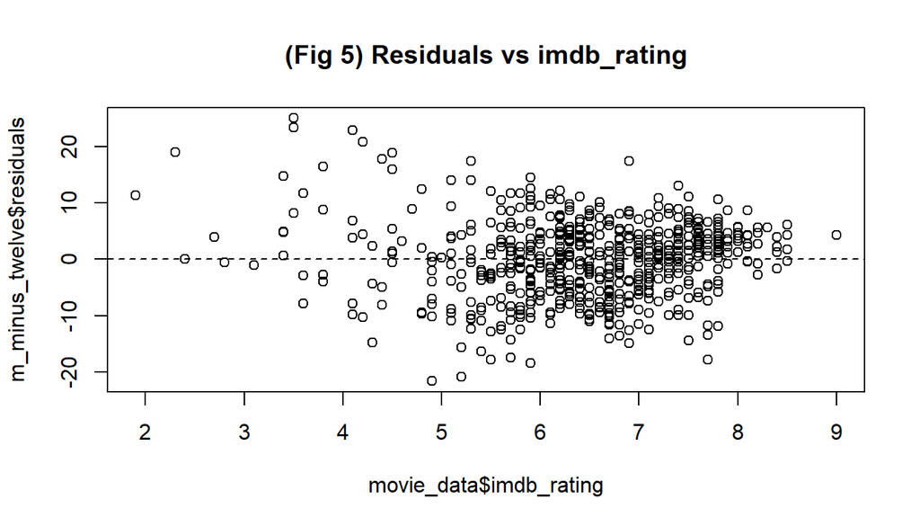

```r
plot(m_minus_twelve$residuals ~ movie_data$imdb_rating, main="(Fig 5) Residuals vs imdb_rating")
abline(h=0, lty = "dashed")
```

There’s clearly a linear relationship between imdb_rating and audience_score, so the linear relationship condition is met.

- Nearly normal residuals with mean 0:

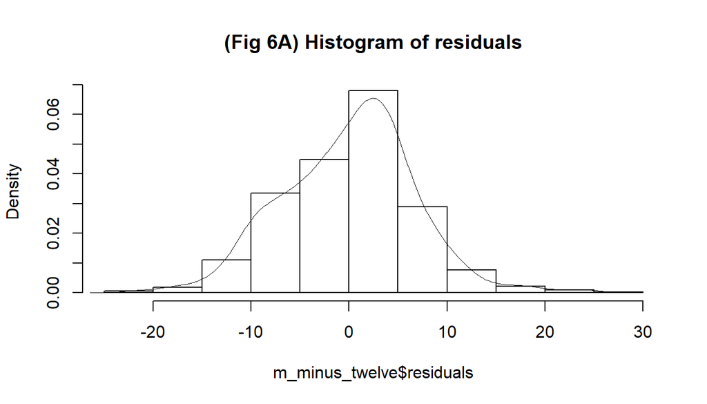

```r
hist(m_minus_twelve$residuals, prob=TRUE, main="(Fig 6A) Histogram of residuals")
lines(density(m_minus_twelve$residuals), lwd=0.25)
```

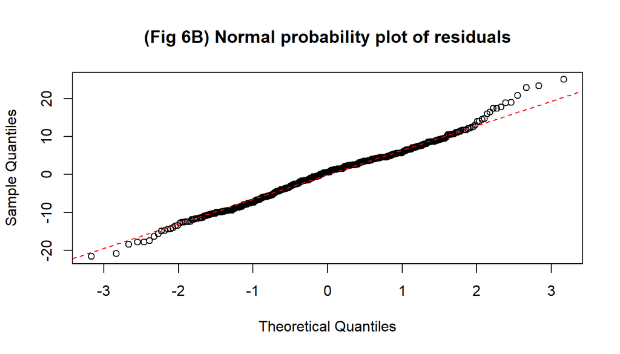

```r
qqnorm(m_minus_twelve$residuals, main="(Fig 6B) Normal probability plot of residuals")
qqline(m_minus_twelve$residuals, col="red", lty="dashed")
```

There are some skewness, but overall the residuals are nearly normal distributed centered at 0, so this condition is also met.

- Constant variability of residuals

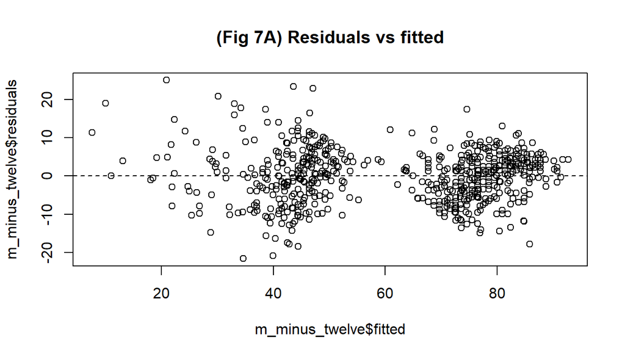

```r
plot(m_minus_twelve$residuals~m_minus_twelve$fitted, main="(Fig 7A) Residuals vs fitted")
abline(h=0, lty="dashed")
```

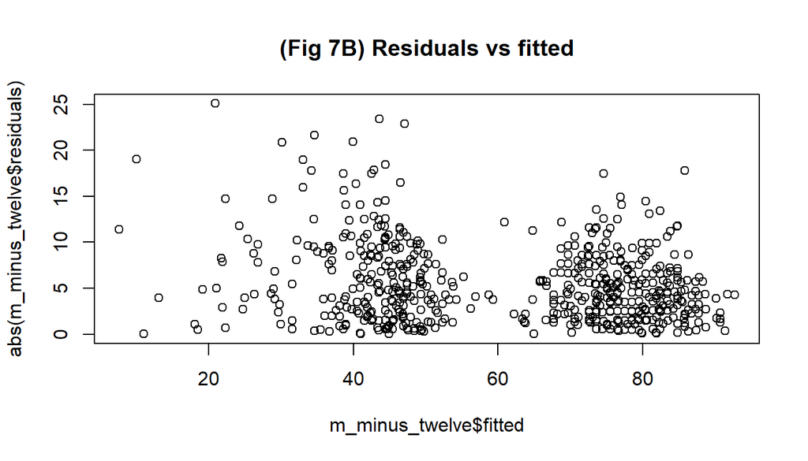

```r
plot(abs(m_minus_twelve$residuals)~m_minus_twelve$fitted, main="(Fig 7B) Residuals vs fitted")
```

There are some clustering but overall residuals are equally variable for low and high values of the predicted response variable. The absolute value of residuals plot does not show unusual observations. Hence the condition of constant variability of residuals is met.

- Independent residuals

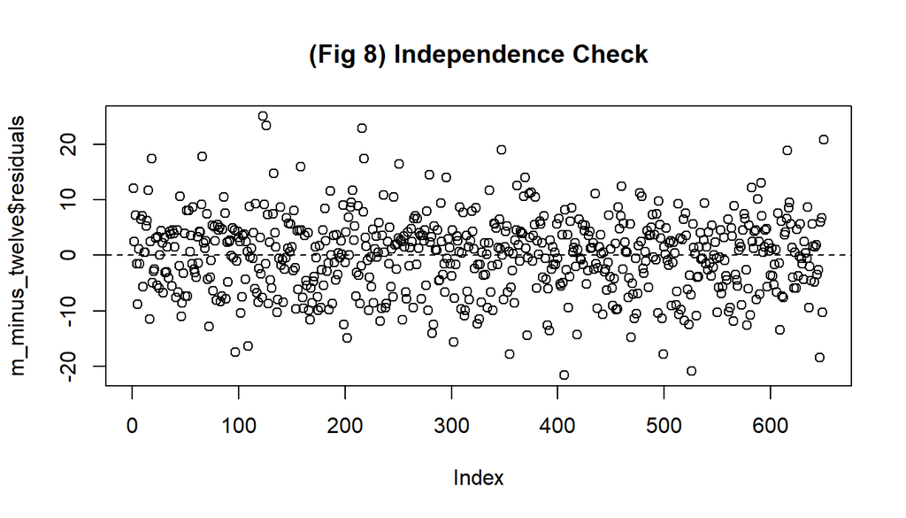

```r
plot(m_minus_twelve$residuals, main="(Fig 8) Independence Check")
abline(h=0, lty="dashed")
```

The plot shows randomly scattered residuals centered around zero, therefore the condition of indepence is met.

## Part 5: Prediction

Here I selected a 2016 movie “The Jungle Book”, and use the linear regression model I selected to predict its audience score based on variables included in the model: imdb_rating, audience_rating and genre.

```r
new_movie <- data.frame(title ="The Jungle Book", imdb_rating = 7.8, genre = "Action & Adventure", audience_rating = "Upright")

predict(m_minus_twelve, new_movie, interval = "confidence")
```

```
##        fit      lwr      upr
## 1 84.21968 82.26334 86.17602
```

## Part 6: Conclusion

By using backward selection with p-value, I developed a linear regression model that takes a movie’s genre, imdb_score and audience_rating as explanatory variables to predict a movie’s audience score, which is a measurement of movie popularity. This model is of great use for entertainment industry to gain insight into the underline driving force for movie popularity and revenue.

One concern is that this model does not take into account of audience’s changing taste of movies over time: the model treats movies produced at different years equally, but it’s quite likely that theatre-goers today have different preference on movies than those 10 years ago. Therefore, a more sophisticated model should add time-series into the prediction, and putting more weight on more recent movies.